# AMES H2O Regression Model

Ricardo De León Flores.

Date: 26 de February de 2024

# Introduction

**H2O** is a powerful open-source platform for machine learning and predictive analytics, designed for handling big data efficiently.

Built in Java, it employs distributed computing techniques, utilizing a Distributed Key/Value store and a Map/Reduce framework for scalability and speed.

Data is stored in memory in a compressed columnar format, enabling fast parallel processing.

H2O offers a REST API for easy access to its capabilities, utilized by its web interface, R binding, and Python binding.

With its support for various cutting-edge algorithms like Deep Learning and Tree Ensembles, H2O is highly valued for its speed, quality, and ease of use in deploying models.

Licensed under Apache License, Version 2.0, it’s a sought-after tool for big data science.

For this example we will use **AMES** dataset in order to demonstrate how **h2o** works with libraries simmilar as the libraries we have been working with.

## **Initialiacion**

```r
h2o.init(ip="localhost",
         #-1 uses all available cores
         nthreads = -1,
         # max mem
         max_mem_size= "8g")
```

```
##  Connection successful!
##
## R is connected to the H2O cluster:
##     H2O cluster uptime:         2 days 46 minutes
##     H2O cluster timezone:       America/Mexico_City
##     H2O data parsing timezone:  UTC
##     H2O cluster version:        3.44.0.3
##     H2O cluster version age:    2 months and 5 days
##     H2O cluster name:           H2O_started_from_R_khrw896_nkv744
##     H2O cluster total nodes:    1
##     H2O cluster total memory:   7.39 GB
##     H2O cluster total cores:    11
##     H2O cluster allowed cores:  11
##     H2O cluster healthy:        TRUE
##     H2O Connection ip:          localhost
##     H2O Connection port:        54321
##     H2O Connection proxy:       NA
##     H2O Internal Security:      FALSE
##     R Version:                  R version 4.3.2 (2023-10-31)
```

```r
h2o.removeAll()
```

## **Data Analysis**

Dataset load

```r
# create a new ames working copy
data <- data.frame(ames)

# add the data to h2o
datos_h2o <- as.h2o(x=data,destination_frame = "datos_h2o")
h2o.no_progress()
```

Analysis

```r
#Dimensiones frame

h2o.dim(datos_h2o)
```

```
## [1] 2930   74
```

```r
#Nombre de las columnas

h2o.colnames(datos_h2o)
```

```
##  [1] "MS_SubClass"        "MS_Zoning"          "Lot_Frontage"
##  [4] "Lot_Area"           "Street"             "Alley"
##  [7] "Lot_Shape"          "Land_Contour"       "Utilities"
## [10] "Lot_Config"         "Land_Slope"         "Neighborhood"
## [13] "Condition_1"        "Condition_2"        "Bldg_Type"
## [16] "House_Style"        "Overall_Cond"       "Year_Built"
## [19] "Year_Remod_Add"     "Roof_Style"         "Roof_Matl"
## [22] "Exterior_1st"       "Exterior_2nd"       "Mas_Vnr_Type"
## [25] "Mas_Vnr_Area"       "Exter_Cond"         "Foundation"
## [28] "Bsmt_Cond"          "Bsmt_Exposure"      "BsmtFin_Type_1"
## [31] "BsmtFin_SF_1"       "BsmtFin_Type_2"     "BsmtFin_SF_2"
## [34] "Bsmt_Unf_SF"        "Total_Bsmt_SF"      "Heating"
## [37] "Heating_QC"         "Central_Air"        "Electrical"
## [40] "First_Flr_SF"       "Second_Flr_SF"      "Gr_Liv_Area"
## [43] "Bsmt_Full_Bath"     "Bsmt_Half_Bath"     "Full_Bath"
## [46] "Half_Bath"          "Bedroom_AbvGr"      "Kitchen_AbvGr"
## [49] "TotRms_AbvGrd"      "Functional"         "Fireplaces"
## [52] "Garage_Type"        "Garage_Finish"      "Garage_Cars"
## [55] "Garage_Area"        "Garage_Cond"        "Paved_Drive"
## [58] "Wood_Deck_SF"       "Open_Porch_SF"      "Enclosed_Porch"
## [61] "Three_season_porch" "Screen_Porch"       "Pool_Area"
## [64] "Pool_QC"            "Fence"              "Misc_Feature"
## [67] "Misc_Val"           "Mo_Sold"            "Year_Sold"
## [70] "Sale_Type"          "Sale_Condition"     "Sale_Price"
## [73] "Longitude"          "Latitude"
```

```r
h2o.describe(datos_h2o)
```

```
##                 Label Type Missing Zeros PosInf NegInf         Min          Max
## 1         MS_SubClass enum       0   109      0      0     0.00000     15.00000
## 2           MS_Zoning enum       0     2      0      0     0.00000      6.00000
## 3        Lot_Frontage  int       0   490      0      0     0.00000    313.00000
## 4            Lot_Area  int       0     0      0      0  1300.00000 215245.00000
## 5              Street enum       0    12      0      0     0.00000      1.00000
## 6               Alley enum       0   120      0      0     0.00000      2.00000
## 7           Lot_Shape enum       0    16      0      0     0.00000      3.00000
## 8        Land_Contour enum       0   117      0      0     0.00000      3.00000
## 9           Utilities enum       0  2927      0      0     0.00000      2.00000
## 10         Lot_Config enum       0   511      0      0     0.00000      4.00000
## 11         Land_Slope enum       0  2789      0      0     0.00000      2.00000
## 12       Neighborhood enum       0    28      0      0     0.00000     27.00000
## 13        Condition_1 enum       0    92      0      0     0.00000      8.00000
## 14        Condition_2 enum       0     5      0      0     0.00000      7.00000
```

[output cut: 135 more lines]

Variable predictora

```r
datos_h2o$Sale_Price
```

```
##   Sale_Price
## 1     215000
## 2     105000
## 3     172000
## 4     244000
## 5     189900
## 6     195500
##
## [2930 rows x 1 column]
```

Grafica de Densidad

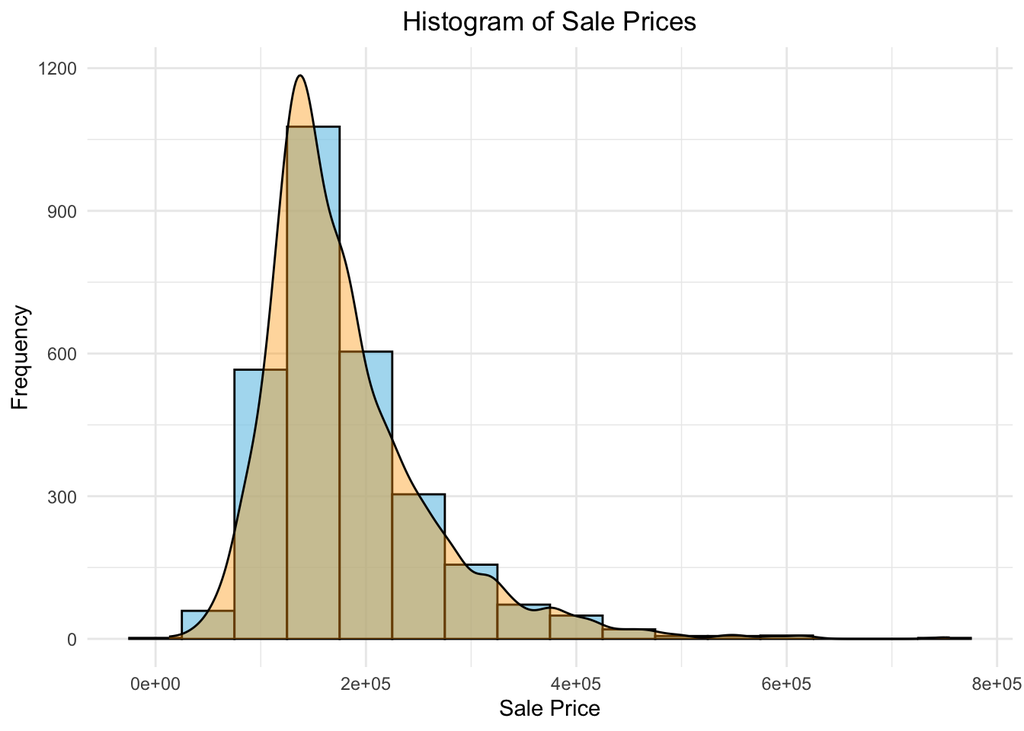

```r
# Convertir Sale_Price a un data frame
sale_price <- as.data.frame(datos_h2o$Sale_Price)

# Graficar el histograma de Sale_Price con línea de densidad
ggplot(sale_price, aes(x = Sale_Price)) +
  geom_histogram(binwidth = 50000, fill = "skyblue", color = "black", alpha = 0.7) + # alpha para transparencia
  geom_density(aes(y = ..count.. * 50000), fill = "orange", alpha = 0.4) +  # Línea de densidad
  labs(x = "Sale Price", y = "Frequency", title = "Histogram of Sale Prices") +
  theme_minimal() +
  theme(plot.title = element_text(hjust = 0.5))
```

## **Regression**

Data preparation split

```r
#Split de los datos

#Train 60%
#Validacion 20%
#Test 20%

h2o.dim(datos_h2o)
```

```
## [1] 2930   74
```

```r
split_h2o <- h2o.splitFrame(data=datos_h2o,ratios = c(0.6,.2),seed = 123)

train_h2o <- h2o.assign(data = split_h2o[[1]],key="train_h2o") #Train 60%
h2o.dim(train_h2o)
```

```
## [1] 1761   74
```

```r
validation_h2o <- h2o.assign(data = split_h2o[[2]],key="validation_h2o") #Validacion 20%
h2o.dim(validation_h2o)
```

```
## [1] 588  74
```

```r
test_h2o <- h2o.assign(data = split_h2o[[3]],key="test_h2o") #Test 20%
h2o.dim(test_h2o)
```

```
## [1] 581  74
```

## **Model Random Forest**

### **Optimization**

```r
# Optimizacion

# Definimos el grid

hypergrid_RF <- list(ntrees = seq(50,500, by=50), # Numero de aarboles
                     mtries = seq(4,5, by=1) # Number de variables que se eligen en cada arbol
)
```

### **Grid Definition**

```r
grid_RF <- h2o.grid(
  # definimos el algoritmo
  algorithm = "randomForest",
  # variable de respuesta
  y = 1,
  # predictores
  x = c(2:16),
  # datos de entrenamiento
  training_frame = train_h2o,
  # datos de validacion
  validation_frame = validation_h2o,
  # preprocesado (varianza cero) quitar todas las variavle que no tengan cambios o que sean constates
  ignore_const_cols=TRUE,
  # merica optimizacion
  stopping_metric = "RMSE",
  # hiperparametros
  hyper_params = hypergrid_RF,
  # tipo de busqueda
  search_criteria = list(strategy="Cartesian"),
  seed=123,
  grid_id = "grid_RF"
)
```

### *Results*

```r
res_grid_RF <- h2o.getGrid(grid_id = "grid_RF",
                           sort_by = "RMSE",
                           decreasing = FALSE)

res_grid_RF
```

```
## H2O Grid Details
## ================
##
## Grid ID: grid_RF
## Used hyper parameters:
##   -  mtries
##   -  ntrees
## Number of models: 20
## Number of failed models: 0
##
## Hyper-Parameter Search Summary: ordered by increasing RMSE
##     mtries    ntrees        model_ids    rmse
## 1  5.00000 100.00000  grid_RF_model_4 0.20845
## 2  5.00000  50.00000  grid_RF_model_2 0.20884
## 3  5.00000 250.00000 grid_RF_model_10 0.20901
## 4  5.00000 300.00000 grid_RF_model_12 0.20904
## 5  5.00000 200.00000  grid_RF_model_8 0.20910
## 6  5.00000 150.00000  grid_RF_model_6 0.20912
## 7  5.00000 400.00000 grid_RF_model_16 0.20951
## 8  5.00000 450.00000 grid_RF_model_18 0.20962
## 9  5.00000 350.00000 grid_RF_model_14 0.20983
## 10 5.00000 500.00000 grid_RF_model_20 0.21013
## 11 4.00000 100.00000  grid_RF_model_3 0.21574
## 12 4.00000 200.00000  grid_RF_model_7 0.21598
## 13 4.00000 250.00000  grid_RF_model_9 0.21619
## 14 4.00000 400.00000 grid_RF_model_15 0.21622
## 15 4.00000 350.00000 grid_RF_model_13 0.21637
## 16 4.00000 450.00000 grid_RF_model_17 0.21659
## 17 4.00000 150.00000  grid_RF_model_5 0.21660
## 18 4.00000 300.00000 grid_RF_model_11 0.21662
## 19 4.00000 500.00000 grid_RF_model_19 0.21721
## 20 4.00000  50.00000  grid_RF_model_1 0.21915
```

Now we save the best model in a variable

```r
best_model_rf_id = res_grid_RF@model_ids[[1]] # el mejor modelo es el 1 por que asi lo pusimos a la hora de hacer el resumen decreasing


# guardar el mejor modelo basado en la metrica rmse del train
best_model_rf <- h2o.getModel(best_model_rf_id)
```

### *Hyperparameters*

```r
# Seleccionamos los mejores hyperparametros
best_hyperparameters <- grid_RF@summary_table[grid_RF@summary_table$model_id== best_model_rf_id,]

# seleccionamos del error rmse
validation_error <- best_model_rf@model$validation_metrics@metrics$RMSE

# tambien r2
validation_r2 <- best_model_rf@model$validation_metrics@metrics$r2

best_hyperparameters
```

```
## Hyper-Parameter Search Summary: ordered by increasing logloss
##    mtries    ntrees       model_ids logloss
## 1 5.00000 100.00000 grid_RF_model_4 0.19001
```

```r
validation_error
```

```
## [1] 0.2084528
```

```r
validation_r2
```

```
## [1] 0.9982756
```

### *Prediction*

```r
# prediccion
pred_RF <- h2o.predict(best_model_rf, test_h2o)

# error del test
rmse_test_rf <- h2o.performance(model = best_model_rf, newdata = test_h2o)@metrics$RMSE
rmse_test_rf
```

```
## [1] 0.1971579
```

### *Comparison*

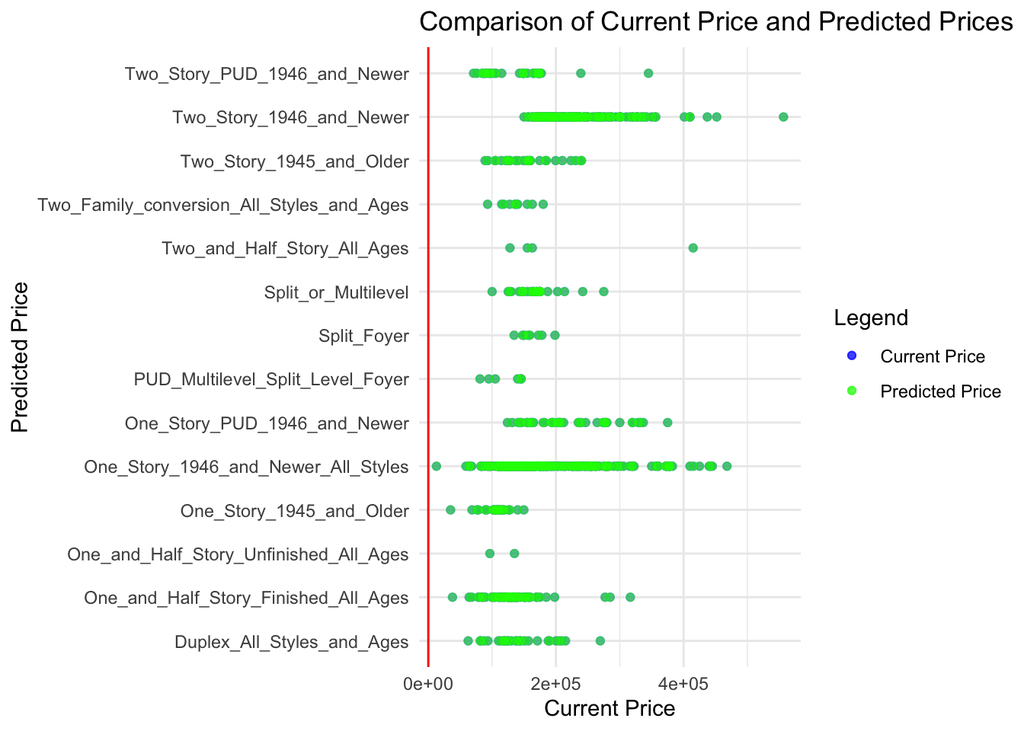

```r
# tomar los precios actulaes
curr_price <- as.data.frame(test_h2o$Sale_Price)

# precios actuales vs predicted
comparison_rf <- cbind(curr_price, as.data.frame(pred_RF$predict))

# nombre de columnas
colnames(comparison_rf) <- c("curr_price", "predicted_price")

# Grafica
ggplot(comparison_rf, aes(x = curr_price, y = predicted_price)) +
  geom_point(aes(color = "Current Price"), alpha = 0.5) +
  geom_point(aes(y = predicted_price, color = "Predicted Price"), alpha = 0.5) +  #
  geom_abline(slope = 1, intercept = 0, color = "red") +
  labs(x = "Current Price", y = "Predicted Price", color = "Legend") +
  scale_color_manual(values = c("Current Price" = "blue", "Predicted Price" = "green")) +  #
  ggtitle("Comparison of Current Price and Predicted Prices") +
  theme_minimal()
```

### *Performance*

```r
test_performance_rf <- h2o.performance(model = best_model_rf, newdata = test_h2o)

# Extract the RMSE and R2 from the test_performance object
test_metrics_rf <- list(
  RMSE = h2o.rmse(test_performance_rf),
  R2 = h2o.r2(test_performance_rf)
)

test_metrics_rf
```

```
## $RMSE
## [1] 0.1971579
##
## $R2
## [1] 0.9984785
```

## **Generalized Linear Model (GLM)**

### *Optimization*

```r
# Definir el grid de búsqueda de hiperparámetros
hyper_params_glm <- list(
  alpha = seq(0, 1, by = 0.1),  # Coeficiente de regularización L1
  lambda = seq(0.0001, 0.1, by = 0.001)  # Coeficiente de regularización L2
)
```

### *Grid Definition*

```r
# Definir los predictores y la variable de respuesta
predictors_glm <- setdiff(h2o.colnames(train_h2o), "Sale_Price")  # Ajustar según tus nombres de columnas
response_glm <- "Sale_Price"

# Crear el grid de búsqueda
grid_glm <- h2o.grid(
  algorithm = "glm",
  grid_id = "grid_glm",
  x = predictors_glm,
  y = response_glm,
  training_frame = train_h2o,
  validation_frame = validation_h2o,
  family = "gaussian",  # Para regresión lineal
  hyper_params = hyper_params_glm,
  ignore_const_cols=TRUE,
  stopping_metric = "MSE"
)
```

### *Results*

```r
# resultados del grid
res_grid_glm <- h2o.getGrid(grid_id = "grid_glm",
                           sort_by = "MSE",
                           decreasing = FALSE)
res_grid_glm
```

```
## H2O Grid Details
## ================
##
## Grid ID: grid_glm
## Used hyper parameters:
##   -  alpha
##   -  lambda
## Number of models: 1100
## Number of failed models: 0
##
## Hyper-Parameter Search Summary: ordered by increasing MSE
##                alpha lambda          model_ids              mse
## 1                0.9 0.0101 grid_glm_model_120 1943183946.63526
## 2                0.8 0.0051  grid_glm_model_64 1943197258.66747
## 3                0.1 0.0011  grid_glm_model_13 1943206632.27845
## 4                0.5 0.0021  grid_glm_model_28 1943222514.31535
## 5 0.7000000000000001 0.0031  grid_glm_model_41 1943264374.29099
##
## ---
##      alpha              lambda          model_ids              mse
## 1095   0.0 0.08310000000000001 grid_glm_model_914 2110733953.05195
## 1096   0.0              0.0781 grid_glm_model_859 2110745248.82528
## 1097   0.0              0.0821 grid_glm_model_903 2110756763.61676
## 1098   0.0              0.0791 grid_glm_model_870 2110764200.00735
## 1099   0.0              0.0811 grid_glm_model_892 2110769621.55874
## 1100   0.0              0.0801 grid_glm_model_881 2110772210.11331
```

Now save the best model in a variable

```r
# Obtener el mejor modelo del grid
best_glm_model_id <- grid_glm@model_ids[[1]]
best_glm_model <- h2o.getModel(best_glm_model_id)
best_glm_model
```

```
## Model Details:
## ==============
##
## H2ORegressionModel: glm
## Model ID:  grid_glm_model_120
## GLM Model: summary
##     family     link                              regularization
## 1 gaussian identity Elastic Net (alpha = 0.9, lambda = 0.0101 )
##   number_of_predictors_total number_of_active_predictors number_of_iterations
## 1                        314                         299                    1
##   training_frame
## 1      train_h2o
##
## Coefficients: glm coefficients
##                              names     coefficients standardized_coefficients
## 1                        Intercept -22787318.661051             199878.245983
## 2 Neighborhood.Bloomington_Heights    -13030.446722             -13030.446722
## 3             Neighborhood.Blueste     14235.268021              14235.268021
## 4           Neighborhood.Briardale     10496.196925              10496.196925
## 5           Neighborhood.Brookside     -3431.215483              -3431.215483
##
## ---
##         names   coefficients standardized_coefficients
## 310 Pool_Area     169.566284               4125.958812
## 311  Misc_Val     -19.531807             -11135.871514
## 312   Mo_Sold    -159.866761               -431.480704
## 313 Year_Sold    -298.429057               -391.589972
## 314 Longitude -101652.029556              -2576.625760
## 315  Latitude  307182.029964               5587.057972
##
## H2ORegressionMetrics: glm
## ** Reported on training data. **
##
## MSE:  476967126
## RMSE:  21839.58
## MAE:  15354.08
## RMSLE:  0.1405427
## Mean Residual Deviance :  476967126
## R^2 :  0.9260619
## Null Deviance :1.136004e+13
## Null D.o.F. :1760
## Residual Deviance :839939109273
## Residual D.o.F. :1461
## AIC :40789.49
##
##
## H2ORegressionMetrics: glm
## ** Reported on validation data. **
##
## MSE:  1943183947
## RMSE:  44081.56
## MAE:  19115.17
## RMSLE:  0.1715924
## Mean Residual Deviance :  1943183947
## R^2 :  0.6790236
## Null Deviance :3.563548e+12
## Null D.o.F. :587
## Residual Deviance :1.142592e+12
## Residual D.o.F. :288
## AIC :14846.58
```

### *Hyperparameters*

```r
# Seleccionamos los mejores hyperparametros
best_hyperparameters_glm <- grid_glm@summary_table[grid_glm@summary_table$model_id == best_glm_model_id,]

# seleccionamos del error rmse
validation_error_glm <- best_glm_model@model$validation_metrics@metrics$MSE

# tambien r2
validation_rmse_glm <- best_model_rf@model$validation_metrics@metrics$RMSE

best_hyperparameters_glm
```

```
## Hyper-Parameter Search Summary: ordered by increasing residual_deviance
##   alpha lambda          model_ids   residual_deviance
## 1   0.9 0.0101 grid_glm_model_120 1142592160621.53003
```

```r
validation_error_glm
```

```
## [1] 1943183947
```

```r
validation_rmse_glm
```

```
## [1] 0.2084528
```

### *Prediction*

```r
# prediccion
pred_glm <- h2o.predict(best_glm_model, test_h2o)

# error del test #MSE
mse_test_glm <- h2o.performance(model = best_glm_model, newdata = test_h2o)@metrics$MSE
mse_test_glm
```

```
## [1] 732956892
```

```r
# error del test #MSE
rmse_test_glm <- h2o.performance(model = best_glm_model, newdata = test_h2o)@metrics$RMSE
rmse_test_glm
```

```
## [1] 27073.18
```

### *Comparison*

[figure not shown]

```r
# tomar los precios actulaes
curr_price <- as.data.frame(test_h2o$Sale_Price)

# precios actuales vs predicted
comparison_glm <- cbind(curr_price, as.data.frame(pred_glm$predict))

# nombre de columnas
colnames(comparison_rf) <- c("curr_price", "predicted_price_glm")

# Grafica
ggplot(comparison_rf, aes(x = curr_price, y = predicted_price_glm)) +
  geom_point(aes(color = "Current Price"), alpha = 0.5) +
  geom_point(aes(y = predicted_price_glm, color = "Predicted Price GLM"), alpha = 0.5) +  #
  geom_abline(slope = 1, intercept = 0, color = "red") +
  labs(x = "Current Price", y = "Predicted Price GLM", color = "Legend") +
  scale_color_manual(values = c("Current Price" = "blue", "Predicted Price GLM" = "green")) +  #
  ggtitle("Current Price vs Predicted Prices GLM") +
  theme_minimal()
```

### *Performance*

```r
test_performance_glm <- h2o.performance(model = best_glm_model, newdata = test_h2o)

# Extract the RMSE and R2 from the test_performance object
test_metrics_glm <- list(
  RMSE = h2o.rmse(test_performance_glm),
  MSE = h2o.r2(test_performance_glm)
)

test_metrics_glm
```

```
## $RMSE
## [1] 27073.18
##
## $MSE
## [1] 0.8864252
```

# Conclusion

**Random Forest**:

**Generalized Linear Model (GLM)**:

However, it’s important to note that the interpretation of the RMSE and MSE values should be done cautiously, considering the specific context of the problem and the units of the target variable. Additionally, other factors such as model complexity, computational resources, and interpretability may also influence the choice of the regression model. Therefore, it’s recommended to consider a holistic evaluation of the models before drawing conclusions or making decisions.